### Linear regression

We start by loading the Olympic 100m men’s data

```r
data <- read.csv("../../data/olympic100m.txt", header=FALSE)
x <- data$V1
t <- data$V2
```

#### Plotting

It’s useful to start with a plot

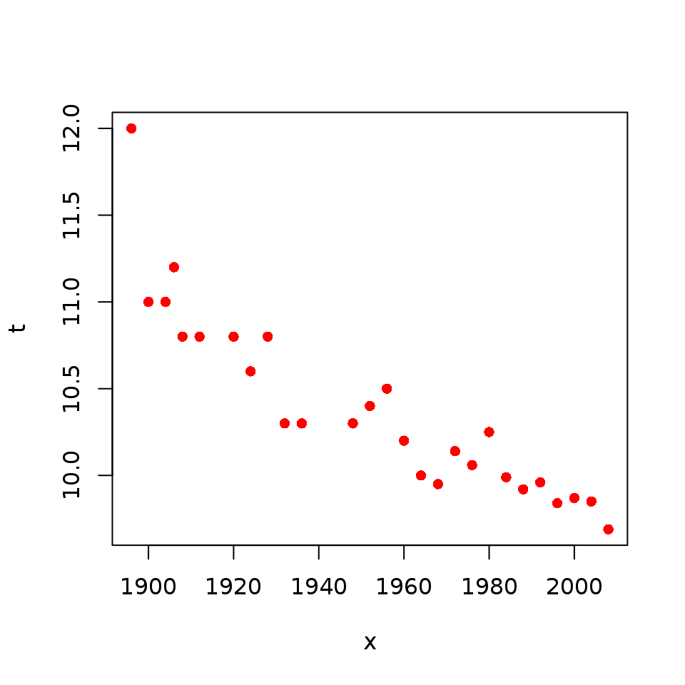

```r
plot(data.frame(x, t), col="red", pch=16)
```

#### Minismising the loss

Recall that the total loss was given by:

$L = \frac{1}{N}\sum_{n=1}^N (t_n - w_0 - w_1x_n)^2$ and the quantities that minimised it by: $w_1 = \frac{\bar{x}\bar{t} - \bar{xt}}{\bar{x}\bar{x} - \bar{x^2}}$ and $w_0 = \bar{t} - w_1\bar{x}$ where $\bar{z} = \frac{1}{N}\sum_{n=1}^N z_n$

```r
xbar  <- mean(x)
tbar  <- mean(t)
xxbar <- mean(x * x)
xtbar <- mean(x * t)
print(xbar)
print(tbar)
print(xxbar)
print(xtbar)
```

```
## [1] 1952.37
## [1] 10.38963
## [1] 3812976
## [1] 20268.07
```

```r
w1 <- (tbar * xbar - xtbar)/(xbar * xbar - xxbar)
w0 <- tbar - w1 * xbar
print(w0)
print(w1)
```

```
## [1] 36.41646
## [1] -0.01333089
```

#### Plotting

We can now plot the fitted model

```r
x_test <- seq(1896, 2008, length=100)
f_test <- w0 + w1 * x_test
plot(data.frame(x, t), col="red", pch=16,
     xlab="Olympic Year", ylab="Winning time (s)")
lines(x_test, f_test, col="blue")
```

[output not shown]

#### Predictions

We can now compute the prediction at 2012:

```r
win_2012 <- w0 + w1 * 2012
print(win_2012)
```

```
## [1] 9.594714
```

#### Matrix and vector form

We first defined $\mathbf{w},\mathbf{x}_n$ as:

$\mathbf{w} = \left[\begin{array}{c} w_0\\w_1\end{array}\right],~~\mathbf{x}_n = \left[\begin{array}{c} 1 \\ x_n \end{array}\right]$ and: $\mathbf{t} = \left[\begin{array}{c} t_1\\ t_2\\ \vdots\\ t_N \end{array}\right]$ and: $\mathbf{X} = \left[\begin{array}{c} \mathbf{x}_1^T \\ \mathbf{x}_2^T \\ \vdots \\ \mathbf{x}_N^T \end{array}\right] = \left[ \begin{array}{cc} 1 & x_1 \\ 1 & x_2 \\ \vdots \\ 1 & x_N \end{array}\right]$ The optimal value of $\mathbf{w}$ is then given by: $\mathbf{w} = \left(\mathbf{X}^T\mathbf{X}\right)^{-1}\mathbf{X}^T\mathbf{t}$

```r
X <- cbind((rep(1, length(x))), x)
w <- solve(t(X) %*% X, t(X) %*% t)
print(w)
```

```
##          [,1]
##   36.41645590
## x -0.01333089
```

```r
f_test <- w[1,] + w[2,] * x_test
plot(data.frame(x, t), col="red", pch=16,
     xlab="Olympic Year", ylab="Winning time (s)")
lines(x_test, f_test, col="blue")
```

[output not shown]

#### Solving linear systems

To obtain the optimal value of $\mathbf{w}$ we re-arranged: $\mathbf{X}^T\mathbf{X}\mathbf{w} = \mathbf{X}^T\mathbf{t}$ It is actually more efficient to solve this equation than explicitly inverting $\mathbf{X}^T\mathbf{X}$.

To do this we can use `solve` which solves equations of the form $\mathbf{A}\mathbf{z} = \mathbf{B}$ for $\mathbf{z}$.

```r
w <- solve(t(X) %*% X, t(X) %*% t)
print(w)
```

```
##          [,1]
##   36.41645590
## x -0.01333089
```

#### Predicting in vector and matrix notation

If we construct a test $\mathbf{X}$ object in the same format as $\mathbf{X}$ (we’ll call it $\mathbf{X}_{*}$), we can obtain predictions via $\mathbf{X}^*\mathbf{w}$.

```r
X_test <- cbind((rep(1, length(x_test))), x_test)
f_test <- X_test %*% w
plot(data.frame(x, t), col="red", pch=16,
     xlab="Olympic Year", ylab="Winning time (s)")
lines(x_test, f_test, col="blue")
```

[output not shown]

Or we can make an $\mathbf{x}_{2012}$ object as: $\mathbf{x}_{2012} = \left[\begin{array}{c} 1 \\ 2012 \end{array}\right]$ and compute the prediction at 2012 as $\mathbf{w}^T\mathbf{x}_{2012}$.

```r
x_2012 <- c(1, 2012)
f_2012 <- t(w) %*% x_2012
print(f_2012)
```

```
##          [,1]
## [1,] 9.594714
```